# Plant Growth Indices

S.Y. CHIA

January 16 2023

# Load required R libraries

```r
library(ggplot2)
library(car)
library(agricolae)
library(ggpubr)
library(emmeans)
library(multcompView)
library(plotrix) # for bar plots
library(lme4)
library(tidyverse)
library(RColorBrewer)
library(GGally)
library(lattice)
library(ggthemes)
library(DHARMa)
library(rmarkdown)
library(dgof)
library(moments)
library(glmmTMB)
```

# Set working directory

```r
setwd("C:/ATP_PROJECT/Data")
```

# Load and prepare the data

## Read in LEAF AREA data - trial 1

## Read in LEAF AREA data - trial 2

## Read in LEAF NUMBER data - trial 1

## Read in LEAF NUMBER data - trial 2

```r
LA1<-read.table("Leafarea_trial_1.txt",header=TRUE)
LA2<-read.table("Leafarea_trial_2.txt",header=TRUE)
LN1<-read.table("Number_of_leaves_trial_1.txt",header=TRUE)
LN2<-read.table("Number_of_leaves_trial_2.txt",header=TRUE)
```

# Save data in appropriate format:

## Set the variable characteristics correctly for LA1, LA2, LN1, LN2

### specify factor and numeric variables

```r
LA1$amendment1 <- as.factor(LA1$amendment1)
LA1$time1 <- as.factor(LA1$time1)
LA1$plant_id1 <- as.factor(LA1$plant_id1)
LA1$trial1 <- as.factor(LA1$trial1)
LA1$leafarea1 <- as.numeric(LA1$leafarea1)
LA1$leaflength1 <- as.numeric(LA1$leaflength1)
LA1$leafwidth1 <- as.numeric(LA1$leafwidth1)

LA2$amendment2 <- as.factor(LA2$amendment2)
LA2$time2 <- as.factor(LA2$time2)
LA2$plant_id2 <- as.factor(LA2$plant_id2)
LA2$trial2 <- as.factor(LA2$trial2)
LA2$leafarea2 <- as.numeric(LA2$leafarea2)
LA2$leaflength2 <- as.numeric(LA2$leaflength2)
LA2$leafwidth2 <- as.numeric(LA2$leafwidth2)

LN1$amendment1 <- as.factor(LN1$amendment1)
LN1$time1 <- as.factor(LN1$time1)
LN1$trial1 <- as.factor(LN1$trial1)
LN1$plant_id1 <- as.factor(LN1$plant_id1)
LN1$no_leaves1 <- as.numeric(LN1$no_leaves1)

LN2$amendment2 <- as.factor(LN2$amendment2)
LN2$time2 <- as.factor(LN2$time2)
LN2$trial2 <- as.factor(LN2$trial2)
LN2$plant_id2 <- as.factor(LN2$plant_id2)
LN2$no_leaves2 <- as.numeric(LN2$no_leaves2)
```

# View data structure and summary stats

```r
str(LA1)
```

```
## 'data.frame':    319 obs. of  7 variables:
##  $ amendment1 : Factor w/ 3 levels "BSFF","MWF","NoFrass": 1 1 1 1 1 1 1 1 1 1 ...
##  $ time1      : Factor w/ 4 levels "21","28","35",..: 1 1 1 1 1 1 1 1 1 1 ...
##  $ trial1     : Factor w/ 1 level "1": 1 1 1 1 1 1 1 1 1 1 ...
##  $ plant_id1  : Factor w/ 30 levels "1","2","3","4",..: 1 2 3 4 5 6 7 8 9 10 ...
##  $ leaflength1: num  6.3 2.2 3.3 2.1 3 3 3.9 3 2.5 2.5 ...
##  $ leafwidth1 : num  4.9 1.6 2 1.6 1.9 1.9 2.6 2.2 2.2 1.8 ...
##  $ leafarea1  : num  25.89 3.77 5.42 3.77 4.98 ...
```

```r
summary(LA1)
```

```
##    amendment1  time1   trial1    plant_id1    leaflength1       leafwidth1
##  BSFF   :101   21:84   1:319   1      : 12   Min.   : 1.600   Min.   : 1.200
##  MWF    :108   28:87           2      : 12   1st Qu.: 3.800   1st Qu.: 2.600
##  NoFrass:110   35:88           3      : 12   Median : 7.000   Median : 4.500
##                42:60           4      : 12   Mean   : 7.852   Mean   : 4.721
##                                5      : 12   3rd Qu.:11.800   3rd Qu.: 6.650
##                                6      : 12   Max.   :18.000   Max.   :10.400
##                                (Other):247
##    leafarea1
##  Min.   :  2.40
##  1st Qu.:  8.43
##  Median : 22.18
##  Mean   : 28.75
##  3rd Qu.: 45.46
##  Max.   :105.70
##
```

```r
str(LA2)
```

```
## 'data.frame':    357 obs. of  7 variables:
##  $ amendment2 : Factor w/ 3 levels "BSFF","MWF","NoFrass": 1 1 1 1 1 1 1 1 1 1 ...
##  $ time2      : Factor w/ 4 levels "21","28","35",..: 1 1 1 1 1 1 1 1 1 1 ...
##  $ trial2     : Factor w/ 1 level "2": 1 1 1 1 1 1 1 1 1 1 ...
##  $ plant_id2  : Factor w/ 30 levels "1","2","3","4",..: 1 2 3 4 5 6 7 8 9 10 ...
##  $ leaflength2: num  4.4 3.2 3.5 3.6 4.2 3.5 3.1 4 4.5 3.2 ...
##  $ leafwidth2 : num  3.7 2.5 2.7 3.2 2.2 2.5 2.6 3 4.1 2.8 ...
##  $ leafarea2  : num  15.61 7.88 8.99 12.08 6.35 ...
```

```r
summary(LA2)
```

```
##    amendment2  time2   trial2    plant_id2    leaflength2       leafwidth2
##  BSFF   :118   21:90   2:357   1      : 12   Min.   : 2.400   Min.   : 1.600
##  MWF    :119   28:90           2      : 12   1st Qu.: 4.700   1st Qu.: 3.600
##  NoFrass:120   35:89           3      : 12   Median : 8.300   Median : 5.700
##                42:88           4      : 12   Mean   : 8.832   Mean   : 5.494
##                                5      : 12   3rd Qu.:12.100   3rd Qu.: 7.100
##                                6      : 12   Max.   :19.800   Max.   :10.300
##                                (Other):285
##    leafarea2
##  Min.   :  3.77
##  1st Qu.: 14.87
##  Median : 34.16
##  Mean   : 35.48
##  3rd Qu.: 51.37
##  Max.   :103.77
##
```

```r
str(LN1)
```

```
## 'data.frame':    352 obs. of  5 variables:
##  $ amendment1: Factor w/ 3 levels "BSFF","MWF","NoFrass": 1 1 1 1 1 1 1 1 1 1 ...
##  $ time1     : Factor w/ 4 levels "21","28","35",..: 1 1 1 1 1 1 1 1 1 1 ...
##  $ trial1    : Factor w/ 1 level "1": 1 1 1 1 1 1 1 1 1 1 ...
##  $ plant_id1 : Factor w/ 30 levels "1","2","3","4",..: 1 2 3 4 5 6 7 8 9 10 ...
##  $ no_leaves1: num  5 3 2 2 3 4 4 3 3 3 ...
```

```r
summary(LN1)
```

```
##    amendment1  time1   trial1    plant_id1     no_leaves1
##  BSFF   :113   21:84   1:352   1      : 12   Min.   : 2.000
##  MWF    :119   28:90           2      : 12   1st Qu.: 4.000
##  NoFrass:120   35:88           3      : 12   Median : 6.000
##                42:90           4      : 12   Mean   : 6.145
##                                5      : 12   3rd Qu.: 8.000
##                                6      : 12   Max.   :13.000
##                                (Other):280
```

```r
str(LN2)
```

```
## 'data.frame':    359 obs. of  5 variables:
##  $ amendment2: Factor w/ 3 levels "BSFF","MWF","NoFrass": 1 1 1 1 1 1 1 1 1 1 ...
##  $ time2     : Factor w/ 4 levels "21","28","35",..: 1 1 1 1 1 1 1 1 1 1 ...
##  $ trial2    : Factor w/ 1 level "2": 1 1 1 1 1 1 1 1 1 1 ...
##  $ plant_id2 : Factor w/ 30 levels "1","2","3","4",..: 1 2 3 4 5 6 7 8 9 10 ...
##  $ no_leaves2: num  5 4 5 4 5 4 4 4 5 4 ...
```

```r
summary(LN2)
```

```
##    amendment2  time2   trial2    plant_id2     no_leaves2
##  BSFF   :119   21:90   2:359   1      : 12   Min.   : 4.000
##  MWF    :120   28:90           2      : 12   1st Qu.: 5.000
##  NoFrass:120   35:90           3      : 12   Median : 6.000
##                42:89           4      : 12   Mean   : 6.735
##                                5      : 12   3rd Qu.: 8.000
##                                6      : 12   Max.   :13.000
##                                (Other):287
```

# Visualize data

## Using boxplots, Q-Q Plots, bar graphs or scatter plots

‘QQ Plot stands for Quantile vs Quantile Plot, which is exactly what it does: plotting theoretical quantiles against the actual quantiles of our variable’.

### Leaf Area (LA): *sample sizes are very large (>30), therefore I ignore the test for normality*

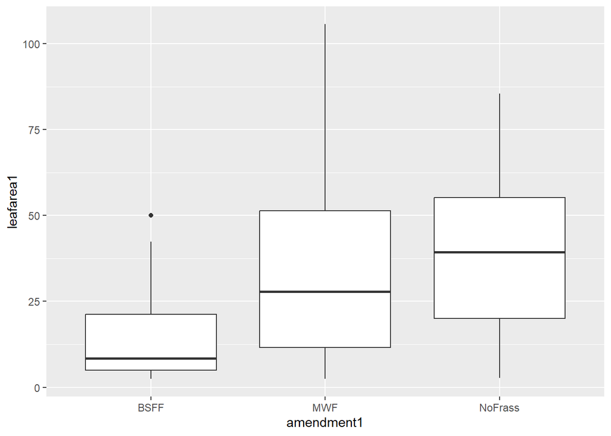

```r
P <- ggplot(data = LA1, aes(x = amendment1, y = leafarea1))
    P + geom_boxplot()
```

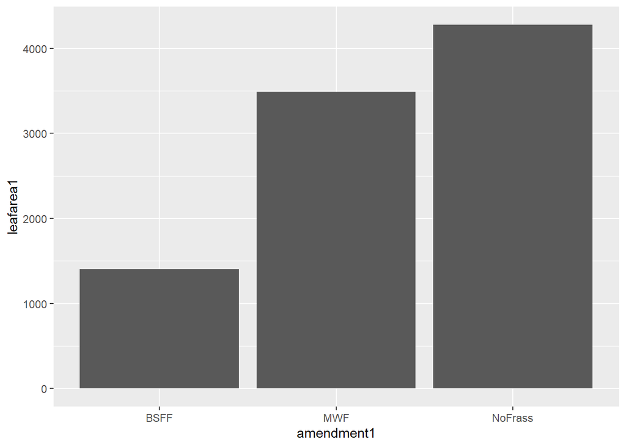

```r
    P + geom_col()
```

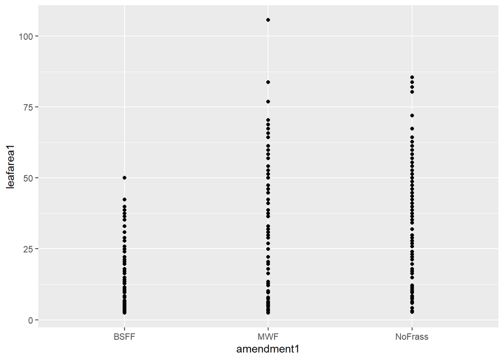

```r
ggplot(data = LA1, aes(x = amendment1, y = leafarea1)) + geom_point()
```

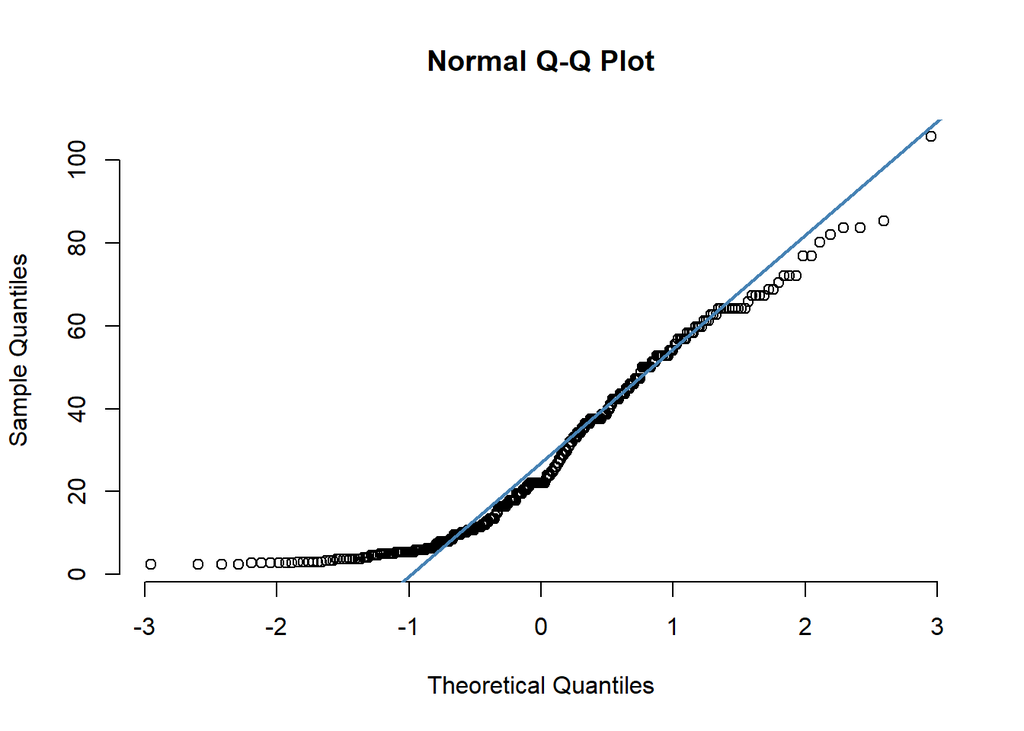

```r
qqnorm(LA1$leafarea1, pch = 1, frame = FALSE)
qqline(LA1$leafarea1, col = "steelblue", lwd = 2)
```

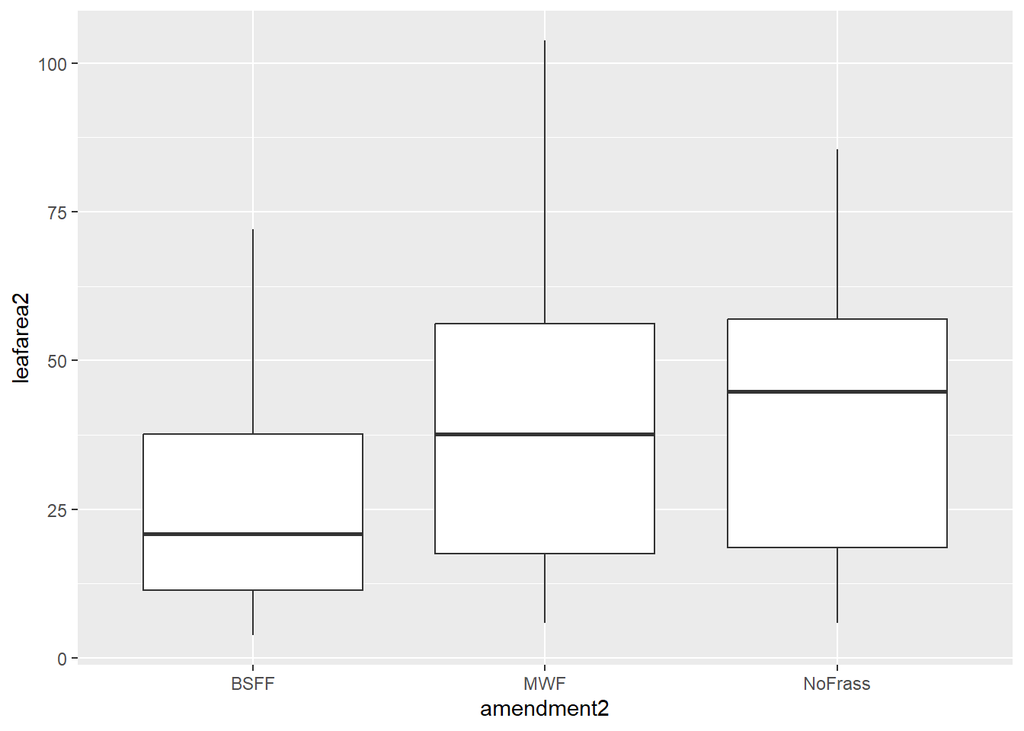

```r
P1 <- ggplot(data = LA2, aes(x = amendment2, y = leafarea2))
    P1 + geom_boxplot()
```

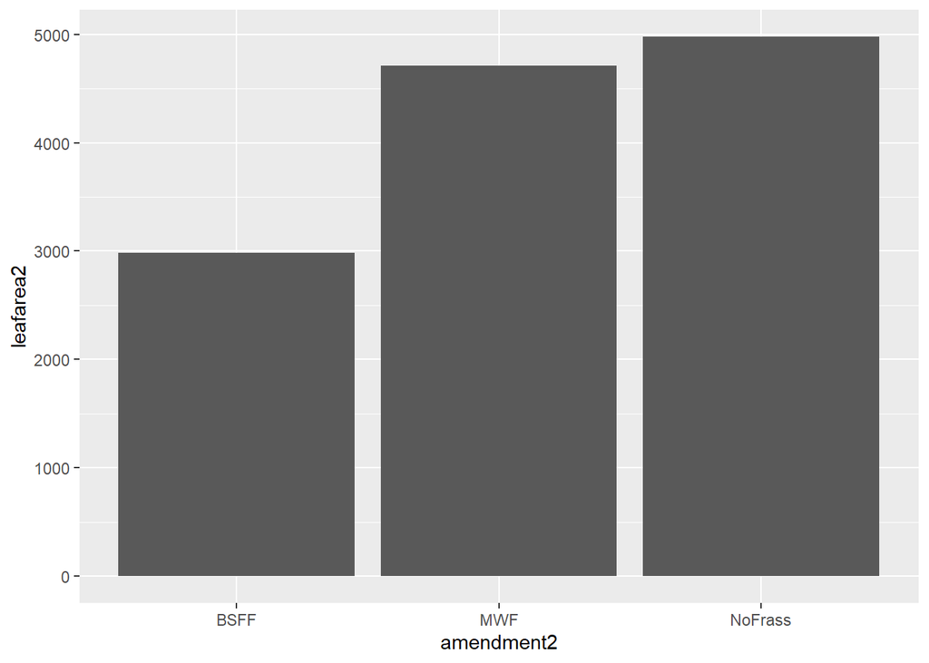

```r
    P1 + geom_col()
```

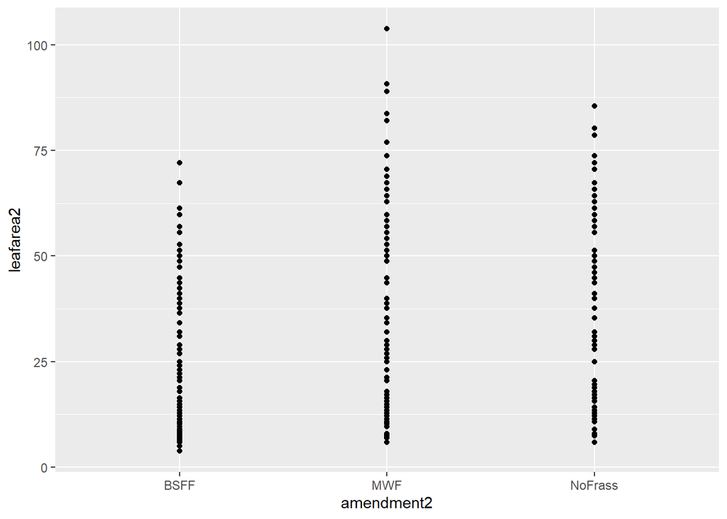

```r
ggplot(data = LA2, aes(x = amendment2, y = leafarea2)) + geom_point()
```

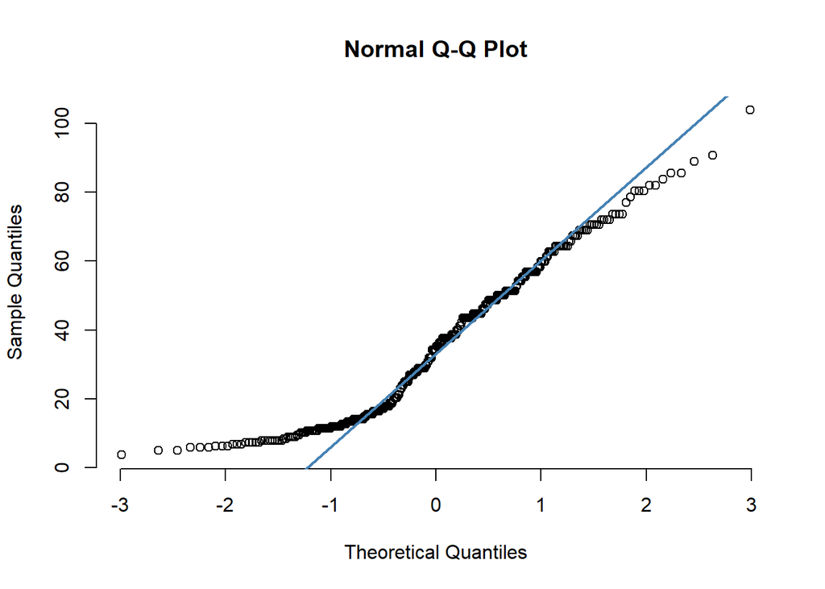

```r
qqnorm(LA2$leafarea2, pch = 1, frame = FALSE)
qqline(LA2$leafarea2, col = "steelblue", lwd = 2)
```

### Number of leaves (LN): *sample sizes are very large (>30), therefore I ignore the test for normality*

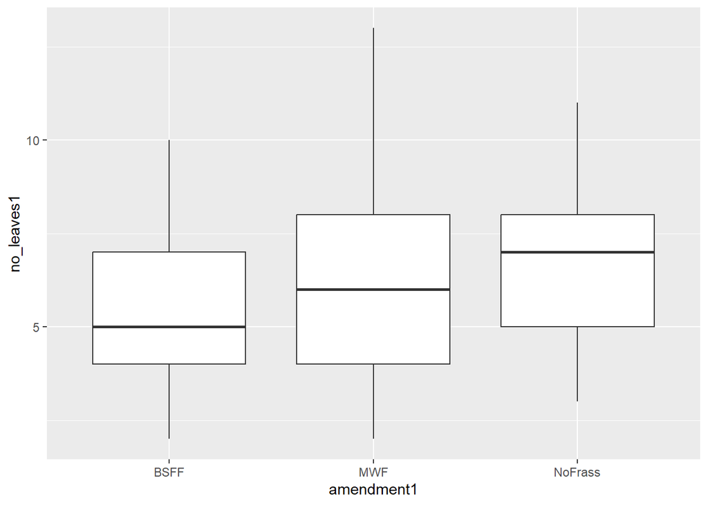

```r
P2 <- ggplot(data = LN1, aes(x = amendment1, y = no_leaves1))
    P2 + geom_boxplot()
```

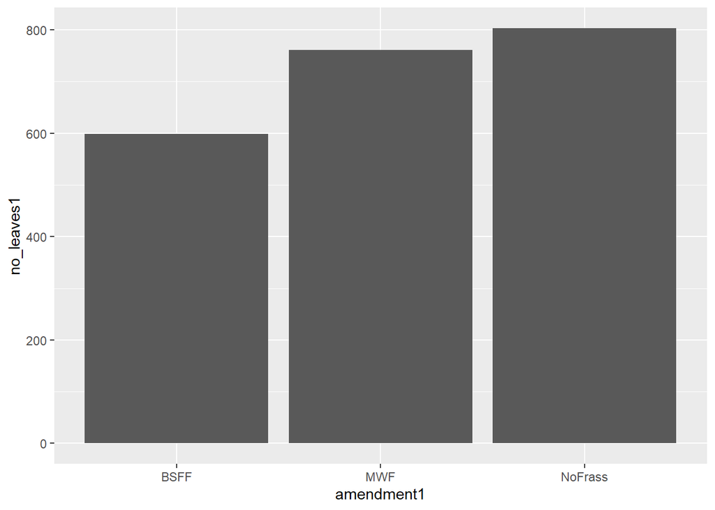

```r
    P2 + geom_col()
```

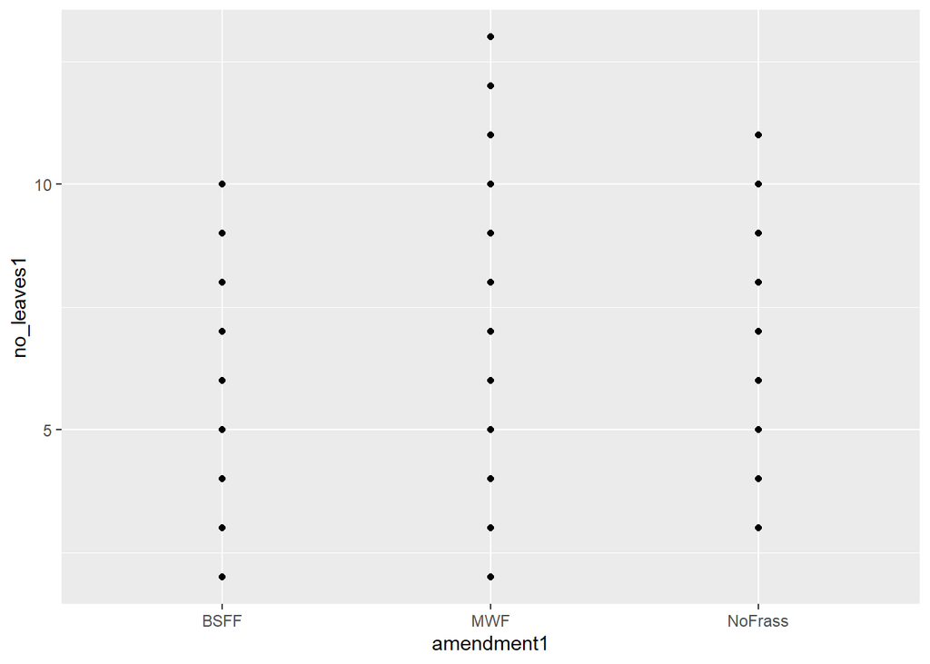

```r
ggplot(data = LN1, aes(x = amendment1, y = no_leaves1)) + geom_point()
```

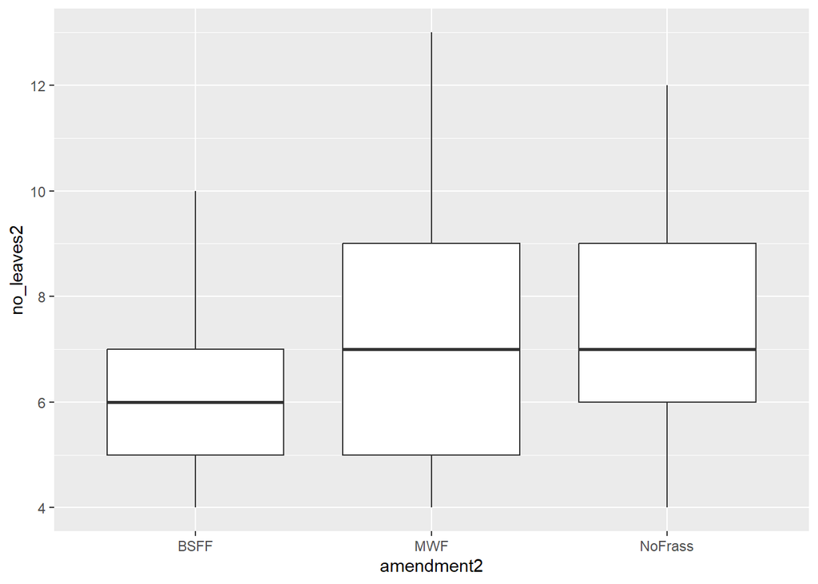

```r
P3 <- ggplot(data = LN2, aes(x = amendment2, y = no_leaves2))
    P3 + geom_boxplot()
```

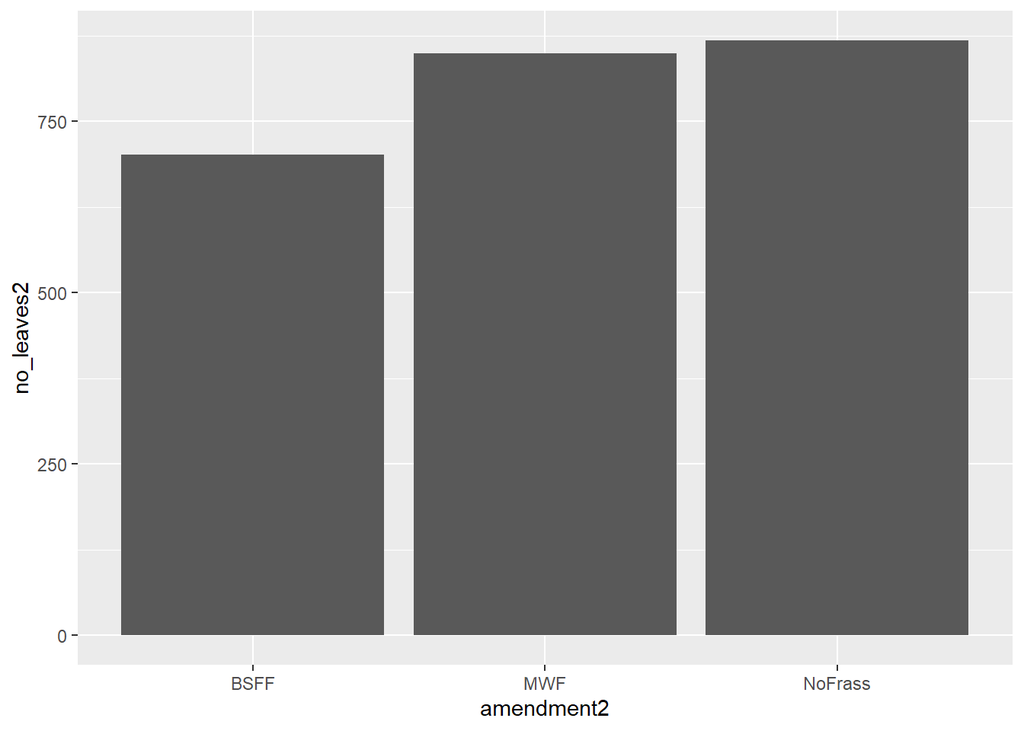

```r
    P3 + geom_col()
```

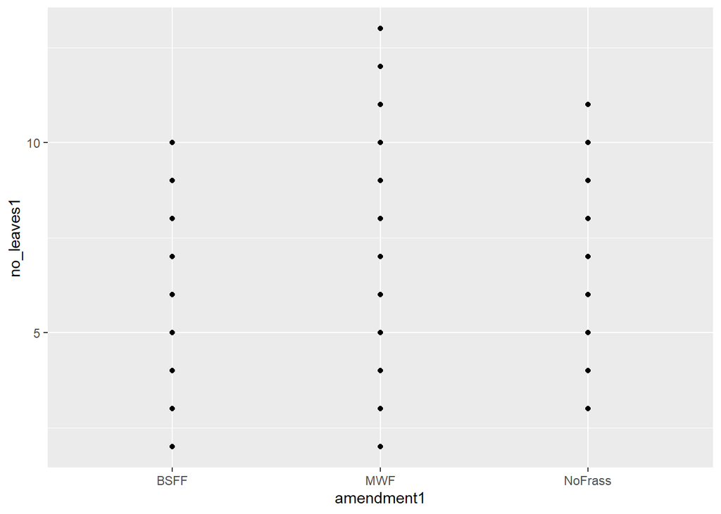

```r
ggplot(data = LN1, aes(x = amendment1, y = no_leaves1)) + geom_point()
```

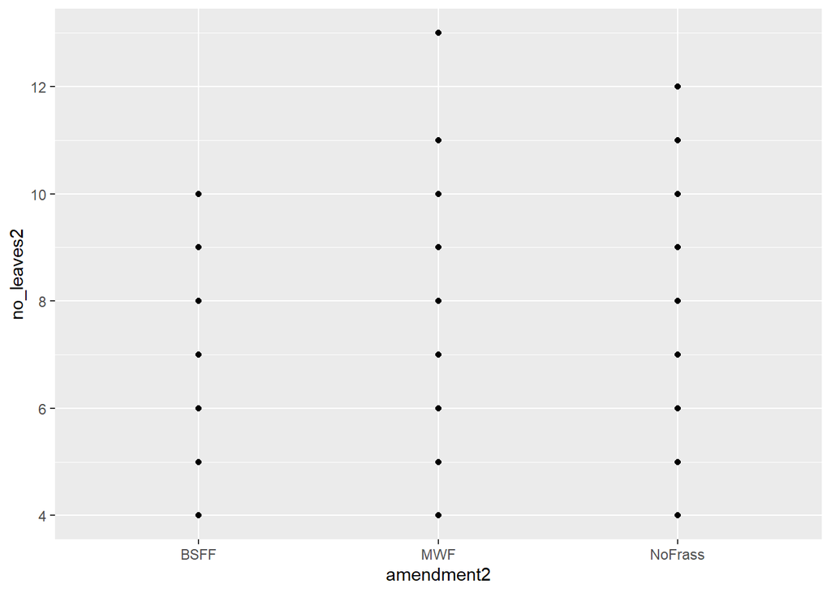

```r
ggplot(data = LN2, aes(x = amendment2, y = no_leaves2)) + geom_point()
```

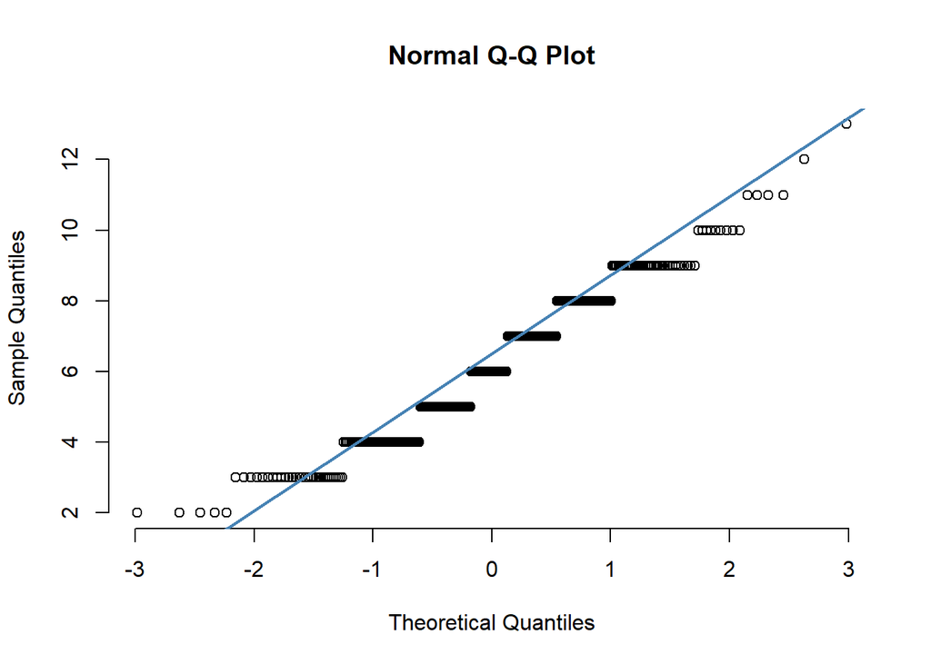

```r
qqnorm(LN1$no_leaves1, pch = 1, frame = FALSE)
qqline(LN2$no_leaves2, col = "steelblue", lwd = 2)
```

# Test for homogeneity of variance

## Homogeneity - Number of leaves (LN)

```r
leveneTest(no_leaves1 ~ amendment1, data = LN1)
```

```
## Levene's Test for Homogeneity of Variance (center = median)
##        Df F value    Pr(>F)
## group   2  8.5707 0.0002324 ***
##       349
## ---
## Signif. codes:  0 '***' 0.001 '**' 0.01 '*' 0.05 '.' 0.1 ' ' 1
```

```r
fligner.test(no_leaves1 ~ amendment1, data = LN1)
```

```
##
##  Fligner-Killeen test of homogeneity of variances
##
## data:  no_leaves1 by amendment1
## Fligner-Killeen:med chi-squared = 15.959, df = 2, p-value = 0.0003424
```

```r
bartlett.test(no_leaves1 ~ amendment1, data = LN1)
```

```
##
##  Bartlett test of homogeneity of variances
##
## data:  no_leaves1 by amendment1
## Bartlett's K-squared = 11.157, df = 2, p-value = 0.003779
```

```r
leveneTest(no_leaves2 ~ amendment2, data = LN2)
```

```
## Levene's Test for Homogeneity of Variance (center = median)
##        Df F value    Pr(>F)
## group   2  8.1081 0.0003602 ***
##       356
## ---
## Signif. codes:  0 '***' 0.001 '**' 0.01 '*' 0.05 '.' 0.1 ' ' 1
```

```r
fligner.test(no_leaves2 ~ amendment2, data = LN2)
```

```
##
##  Fligner-Killeen test of homogeneity of variances
##
## data:  no_leaves2 by amendment2
## Fligner-Killeen:med chi-squared = 16.666, df = 2, p-value = 0.0002405
```

```r
bartlett.test(no_leaves2 ~ amendment2, data = LN2)
```

```
##
##  Bartlett test of homogeneity of variances
##
## data:  no_leaves2 by amendment2
## Bartlett's K-squared = 14.073, df = 2, p-value = 0.0008791
```

# Test for Normality of variances:

If the sample size is large enough (n > 30), we can ignore the distribution of the data and use parametric tests. The **central limit theorem** tells us that no matter what distribution things have, the sampling distribution tends to be normal if the sample is large enough (n > 30).

## **Shapiro-Wilk test** (recommended by Ghasemi & Zahediasl, 2002, doi: 10.5812/ijem.3505). It provides better power than K-S. It is based on the correlation between the data and the corresponding normal scores. **If the p-value is less than or equal to the significance level, the decision is to reject the null hypothesis and conclude that your data do not follow a normal distribution**.

## Leaf Area, Leaf number

```r
shapiro.test(LA1$leafarea1)
```

```
##
##  Shapiro-Wilk normality test
##
## data:  LA1$leafarea1
## W = 0.91551, p-value = 2.058e-12
```

```r
shapiro.test(LA2$leafarea2)
```

```
##
##  Shapiro-Wilk normality test
##
## data:  LA2$leafarea2
## W = 0.94408, p-value = 2.328e-10
```

```r
shapiro.test(LN1$no_leaves1)
```

```
##
##  Shapiro-Wilk normality test
##
## data:  LN1$no_leaves1
## W = 0.95943, p-value = 2.699e-08
```

```r
shapiro.test(LN2$no_leaves2)
```

```
##
##  Shapiro-Wilk normality test
##
## data:  LN2$no_leaves2
## W = 0.93419, p-value = 1.683e-11
```

# Model seection

## *Gamma distribution is best based on the AIC values*

```r
lmer.LA1 <- lmer(leafarea1 ~ amendment1 + (1|time1) + (1|plant_id1), data = LA1)
glmmTMB.LA1 <- glmmTMB(leafarea1 ~ amendment1 + (1|time1) + (1|plant_id1), data = LA1)
gamma.LA1 <- glmer(leafarea1 ~ amendment1 + (1|time1) + (1|plant_id1), family = Gamma(link = "log"),  data = LA1)
AIC(lmer.LA1, glmmTMB.LA1, gamma.LA1)
```

```
##             df      AIC
## lmer.LA1     6 2621.032
## glmmTMB.LA1  6 2632.832
## gamma.LA1    6 2511.769
```

```r
lmer.LA2 <- lmer(leafarea2 ~ amendment2 + (1|time2) + (1|plant_id2), data = LA2)
glmmTMB.LA2 <- glmmTMB(leafarea2 ~ amendment2 + (1|time2) + (1|plant_id2), data = LA2)
gamma.LA2 <- glmer(leafarea2 ~ amendment2 + (1|time2) + (1|plant_id2), family = Gamma(link = "log"),  data = LA2)
AIC(lmer.LA2, glmmTMB.LA2, gamma.LA2)
```

```
##             df      AIC
## lmer.LA2     6 2848.292
## glmmTMB.LA2  6 2859.739
## gamma.LA2    6 2721.658
```

```r
lmer.LN1 <- lmer(no_leaves1 ~ amendment1 + (1|time1) + (1|plant_id1), data = LN1)
glmmTMB.LN1 <- glmmTMB(no_leaves1 ~ amendment1 + (1|time1) + (1|plant_id1), data = LN1)
gamma.LN1 <- glmer(no_leaves1 ~ amendment1 + (1|time1) + (1|plant_id1), family = Gamma(link = "log"),  data = LN1)
AIC(lmer.LN1, glmmTMB.LN1, gamma.LN1)
```

```
##             df      AIC
## lmer.LN1     6 1130.220
## glmmTMB.LN1  6 1127.505
## gamma.LN1    6 1117.922
```

```r
lmer.LN2 <- lmer(no_leaves2 ~ amendment2 + (1|time2) + (1|plant_id2), data = LN2)
glmmTMB.LN2 <- glmmTMB(no_leaves2 ~ amendment2 + (1|time2) + (1|plant_id2), data = LN2)
gamma.LN2 <- glmer(no_leaves2 ~ amendment2 + (1|time2) + (1|plant_id2), family = Gamma(link = "log"),  data = LN2)
AIC(lmer.LN2, glmmTMB.LN2, gamma.LN2)
```

```
##             df       AIC
## lmer.LN2     6 1020.3284
## glmmTMB.LN2  6 1016.7233
## gamma.LN2    6  920.4608
```

# Data analysis

## Leaf Area and Number of leaves data

### Fit a mixed model: amendment effect is fixed, time and plant_id are random and independent.

### Selected model *(Gamma distribution)*

#### *effect of soil amendment was significant on leaf area and number of leaves*

```r
gamma.LA1 <- glmer(leafarea1 ~ amendment1 + (1|time1) + (1|plant_id1), family = Gamma(link = "log"),  data = LA1)
summary(gamma.LA1)
```

```
## Generalized linear mixed model fit by maximum likelihood (Laplace
##   Approximation) [glmerMod]
##  Family: Gamma  ( log )
## Formula: leafarea1 ~ amendment1 + (1 | time1) + (1 | plant_id1)
##    Data: LA1
##
##      AIC      BIC   logLik deviance df.resid
##   2511.8   2534.4  -1249.9   2499.8      313
##
## Scaled residuals:
##     Min      1Q  Median      3Q     Max
## -1.5291 -0.6986 -0.0653  0.5063  5.0779
##
## Random effects:
##  Groups    Name        Variance Std.Dev.
##  plant_id1 (Intercept) 0.02814  0.1677
##  time1     (Intercept) 0.11226  0.3350
##  Residual              0.31859  0.5644
## Number of obs: 319, groups:  plant_id1, 30; time1, 4
##
## Fixed effects:
##                   Estimate Std. Error t value Pr(>|z|)
## (Intercept)        2.51543    0.30005   8.383   <2e-16 ***
## amendment1MWF      0.77723    0.07890   9.850   <2e-16 ***
## amendment1NoFrass  1.04710    0.07926  13.212   <2e-16 ***
## ---
## Signif. codes:  0 '***' 0.001 '**' 0.01 '*' 0.05 '.' 0.1 ' ' 1
##
## Correlation of Fixed Effects:
##             (Intr) am1MWF
## amndmnt1MWF -0.137
## amndmnt1NFr -0.140  0.518
```

```r
Anova(gamma.LA1)
```

```
## Analysis of Deviance Table (Type II Wald chisquare tests)
##
## Response: leafarea1
##             Chisq Df Pr(>Chisq)
## amendment1 186.87  2  < 2.2e-16 ***
## ---
## Signif. codes:  0 '***' 0.001 '**' 0.01 '*' 0.05 '.' 0.1 ' ' 1
```

```r
gamma.LA2 <- glmer(leafarea2 ~ amendment2 + (1|time2) + (1|plant_id2), family = Gamma(link = "log"),  data = LA2)
summary(gamma.LA2)
```

```
## Generalized linear mixed model fit by maximum likelihood (Laplace
##   Approximation) [glmerMod]
##  Family: Gamma  ( log )
## Formula: leafarea2 ~ amendment2 + (1 | time2) + (1 | plant_id2)
##    Data: LA2
##
##      AIC      BIC   logLik deviance df.resid
##   2721.7   2744.9  -1354.8   2709.7      351
##
## Scaled residuals:
##      Min       1Q   Median       3Q      Max
## -2.43271 -0.61588  0.01373  0.63682  2.42257
##
## Random effects:
##  Groups    Name        Variance Std.Dev.
##  plant_id2 (Intercept) 0.01024  0.1012
##  time2     (Intercept) 0.05024  0.2241
##  Residual              0.11541  0.3397
## Number of obs: 357, groups:  plant_id2, 30; time2, 4
##
## Fixed effects:
##                   Estimate Std. Error t value Pr(>|z|)
## (Intercept)        3.09323    0.31392   9.854   <2e-16 ***
## amendment2MWF      0.41013    0.04657   8.807   <2e-16 ***
## amendment2NoFrass  0.47530    0.04657  10.206   <2e-16 ***
## ---
## Signif. codes:  0 '***' 0.001 '**' 0.01 '*' 0.05 '.' 0.1 ' ' 1
##
## Correlation of Fixed Effects:
##             (Intr) am2MWF
## amndmnt2MWF -0.075
## amndmnt2NFr -0.076  0.510
```

```r
Anova(gamma.LA2)
```

```
## Analysis of Deviance Table (Type II Wald chisquare tests)
##
## Response: leafarea2
##             Chisq Df Pr(>Chisq)
## amendment2 121.68  2  < 2.2e-16 ***
## ---
## Signif. codes:  0 '***' 0.001 '**' 0.01 '*' 0.05 '.' 0.1 ' ' 1
```

```r
gamma.LN1 <- glmer(no_leaves1 ~ amendment1 + (1|time1) + (1|plant_id1), family = Gamma(link = "log"), data = LN1)
summary(gamma.LN1)
```

```
## Generalized linear mixed model fit by maximum likelihood (Laplace
##   Approximation) [glmerMod]
##  Family: Gamma  ( log )
## Formula: no_leaves1 ~ amendment1 + (1 | time1) + (1 | plant_id1)
##    Data: LN1
##
##      AIC      BIC   logLik deviance df.resid
##   1117.9   1141.1   -553.0   1105.9      346
##
## Scaled residuals:
##     Min      1Q  Median      3Q     Max
## -3.1996 -0.5523  0.0161  0.6161  2.4806
##
## Random effects:
##  Groups    Name        Variance Std.Dev.
##  plant_id1 (Intercept) 0.004268 0.06533
##  time1     (Intercept) 0.010125 0.10062
##  Residual              0.038493 0.19620
## Number of obs: 352, groups:  plant_id1, 30; time1, 4
##
## Fixed effects:
##                   Estimate Std. Error t value Pr(>|z|)
## (Intercept)        1.59692    0.18816   8.487  < 2e-16 ***
## amendment1MWF      0.19090    0.02500   7.636 2.25e-14 ***
## amendment1NoFrass  0.25772    0.02497  10.322  < 2e-16 ***
## ---
## Signif. codes:  0 '***' 0.001 '**' 0.01 '*' 0.05 '.' 0.1 ' ' 1
##
## Correlation of Fixed Effects:
##             (Intr) am1MWF
## amndmnt1MWF -0.068
## amndmnt1NFr -0.069  0.514
```

```r
Anova(gamma.LN1)
```

```
## Analysis of Deviance Table (Type II Wald chisquare tests)
##
## Response: no_leaves1
##             Chisq Df Pr(>Chisq)
## amendment1 113.94  2  < 2.2e-16 ***
## ---
## Signif. codes:  0 '***' 0.001 '**' 0.01 '*' 0.05 '.' 0.1 ' ' 1
```

```r
gamma.LN2 <- glmer(no_leaves2 ~ amendment2 + (1|time2) + (1|plant_id2), family = Gamma(link = "log"),  data = LN2)
summary(gamma.LN2)
```

```
## Generalized linear mixed model fit by maximum likelihood (Laplace
##   Approximation) [glmerMod]
##  Family: Gamma  ( log )
## Formula: no_leaves2 ~ amendment2 + (1 | time2) + (1 | plant_id2)
##    Data: LN2
##
##      AIC      BIC   logLik deviance df.resid
##    920.5    943.8   -454.2    908.5      353
##
## Scaled residuals:
##     Min      1Q  Median      3Q     Max
## -3.8438 -0.4674 -0.0623  0.6091  2.6091
##
## Random effects:
##  Groups    Name        Variance Std.Dev.
##  plant_id2 (Intercept) 0.001765 0.04201
##  time2     (Intercept) 0.005333 0.07303
##  Residual              0.017666 0.13291
## Number of obs: 359, groups:  plant_id2, 30; time2, 4
##
## Fixed effects:
##                   Estimate Std. Error t value Pr(>|z|)
## (Intercept)        1.74946    0.16150   10.83   <2e-16 ***
## amendment2MWF      0.16574    0.01625   10.20   <2e-16 ***
## amendment2NoFrass  0.19058    0.01624   11.74   <2e-16 ***
## ---
## Signif. codes:  0 '***' 0.001 '**' 0.01 '*' 0.05 '.' 0.1 ' ' 1
##
## Correlation of Fixed Effects:
##             (Intr) am2MWF
## amndmnt2MWF -0.050
## amndmnt2NFr -0.050  0.503
```

```r
Anova(gamma.LN2)
```

```
## Analysis of Deviance Table (Type II Wald chisquare tests)
##
## Response: no_leaves2
##             Chisq Df Pr(>Chisq)
## amendment2 162.53  2  < 2.2e-16 ***
## ---
## Signif. codes:  0 '***' 0.001 '**' 0.01 '*' 0.05 '.' 0.1 ' ' 1
```

# Posthoc test

## *Tukey test using the emmeans (estimated marginal means) package*

```r
HSD_test <- emmeans(ref_grid(gamma.LA1, regrid = "response"), pairwise ~ amendment1)
emmeans(ref_grid(gamma.LA1, regrid = "response"), pairwise ~ amendment1)
```

```
## $emmeans
##  amendment1 response    SE  df asymp.LCL asymp.UCL
##  BSFF           12.4  3.71 Inf       5.1      19.6
##  MWF            26.9  8.06 Inf      11.1      42.7
##  NoFrass        35.3 10.56 Inf      14.6      55.9
##
## Confidence level used: 0.95
##
## $contrasts
##  contrast       estimate   SE  df z.ratio p.value
##  BSFF - MWF       -14.54 4.58 Inf  -3.173  0.0043
##  BSFF - NoFrass   -22.88 7.04 Inf  -3.249  0.0033
##  MWF - NoFrass     -8.34 3.45 Inf  -2.414  0.0417
##
## P value adjustment: tukey method for comparing a family of 3 estimates
```

```r
HSD_test <- emmeans(ref_grid(gamma.LA2, regrid = "response"), pairwise ~ amendment2)
emmeans(ref_grid(gamma.LA2, regrid = "response"), pairwise ~ amendment2)
```

```
## $emmeans
##  amendment2 response    SE  df asymp.LCL asymp.UCL
##  BSFF           22.0  6.92 Inf      8.48      35.6
##  MWF            33.2 10.43 Inf     12.79      53.7
##  NoFrass        35.5 11.13 Inf     13.65      57.3
##
## Confidence level used: 0.95
##
## $contrasts
##  contrast       estimate   SE  df z.ratio p.value
##  BSFF - MWF       -11.18 3.73 Inf  -3.000  0.0076
##  BSFF - NoFrass   -13.42 4.41 Inf  -3.045  0.0066
##  MWF - NoFrass     -2.24 1.73 Inf  -1.293  0.3992
##
## P value adjustment: tukey method for comparing a family of 3 estimates
```

```r
HSD_test <- emmeans(ref_grid(gamma.LN1, regrid = "response"), pairwise ~ amendment1)
emmeans(ref_grid(gamma.LN1, regrid = "response"), pairwise ~ amendment1)
```

```
## $emmeans
##  amendment1 response    SE  df asymp.LCL asymp.UCL
##  BSFF           4.94 0.929 Inf      3.12      6.76
##  MWF            5.98 1.124 Inf      3.77      8.18
##  NoFrass        6.39 1.202 Inf      4.03      8.74
##
## Confidence level used: 0.95
##
## $contrasts
##  contrast       estimate    SE  df z.ratio p.value
##  BSFF - MWF       -1.039 0.238 Inf  -4.369  <.0001
##  BSFF - NoFrass   -1.452 0.307 Inf  -4.734  <.0001
##  MWF - NoFrass    -0.413 0.171 Inf  -2.417  0.0414
##
## P value adjustment: tukey method for comparing a family of 3 estimates
```

```r
HSD_test <- emmeans(ref_grid(gamma.LN2, regrid = "response"), pairwise ~ amendment2)
emmeans(ref_grid(gamma.LN2, regrid = "response"), pairwise ~ amendment2)
```

```
## $emmeans
##  amendment2 response    SE  df asymp.LCL asymp.UCL
##  BSFF           5.75 0.929 Inf      3.93      7.57
##  MWF            6.79 1.096 Inf      4.64      8.94
##  NoFrass        6.96 1.124 Inf      4.76      9.16
##
## Confidence level used: 0.95
##
## $contrasts
##  contrast       estimate    SE  df z.ratio p.value
##  BSFF - MWF       -1.037 0.196 Inf  -5.295  <.0001
##  BSFF - NoFrass   -1.208 0.220 Inf  -5.477  <.0001
##  MWF - NoFrass    -0.171 0.115 Inf  -1.489  0.2963
##
## P value adjustment: tukey method for comparing a family of 3 estimates
```

# Plots for leafarea (cm^2) , Number of leaves

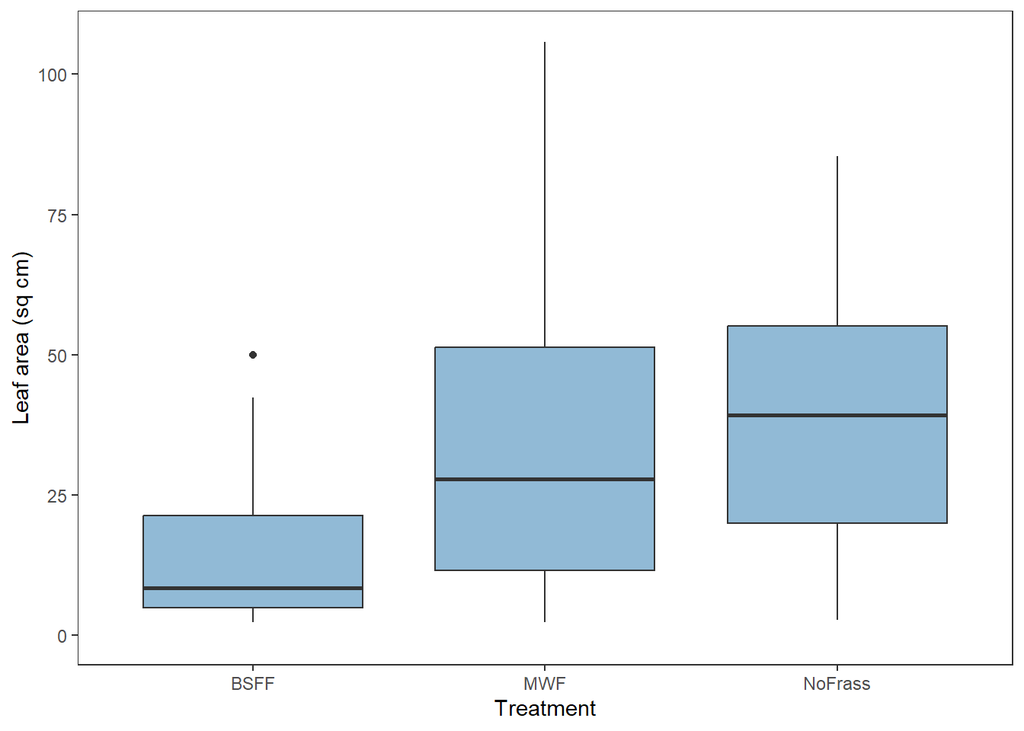

```r
P4 <- ggplot(LA1, aes(amendment1, leafarea1))+
  geom_boxplot(aes(fill = amendment1),
  notch = FALSE, position = position_dodge(0.9), show.legend = FALSE) +
  theme_minimal() + labs(x = "Treatment", y = "Leaf area (sq cm)")+
  theme_bw() + theme(panel.grid.major = element_blank(),# removes grid background
  panel.grid.minor = element_blank())+
  scale_fill_manual(values = c("#91BAD6", "#91BAD6","#91BAD6"))# Dark Sky Blue
P4 + ylim(0, 106)
```

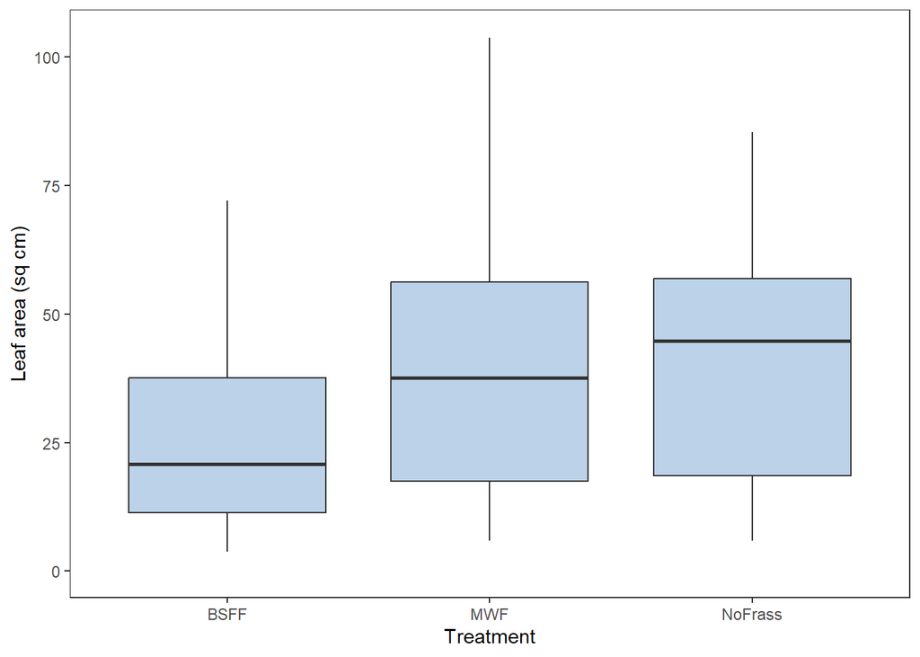

```r
ggsave("boxplot_P4.jpeg", width = 4, height = 3, dpi = 1000)


P5 <- ggplot(LA2, aes(amendment2, leafarea2))+
  geom_boxplot(aes(fill = amendment2),
  notch = FALSE, position = position_dodge(0.9), show.legend = FALSE) +
  theme_minimal() + labs(x = "Treatment", y = "Leaf area (sq cm)")+
  theme_bw() + theme(panel.grid.major = element_blank(),
  panel.grid.minor = element_blank())+
  scale_fill_manual(values = c("#BCD2E8", "#BCD2E8","#BCD2E8")) # Beau Blue
P5 + ylim(0, 104)
```

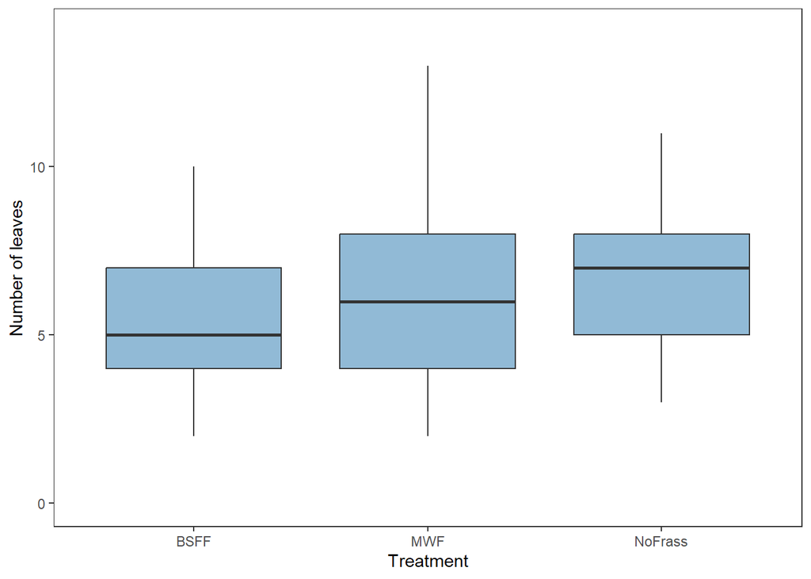

```r
ggsave("boxplot_P5.jpeg", width = 4, height = 3, dpi = 1000)


P6 <- ggplot(LN1, aes(amendment1, no_leaves1))+
  geom_boxplot(aes(fill = amendment1),
  notch = FALSE, position = position_dodge(0.9), show.legend = FALSE) +
  theme_minimal() + labs(x = "Treatment", y = "Number of leaves")+
  theme_bw() + theme(panel.grid.major = element_blank(),
  panel.grid.minor = element_blank())+
  scale_fill_manual(values = c("#91BAD6", "#91BAD6","#91BAD6"))# Dark Sky Blue
P6 + ylim(0, 14)
```

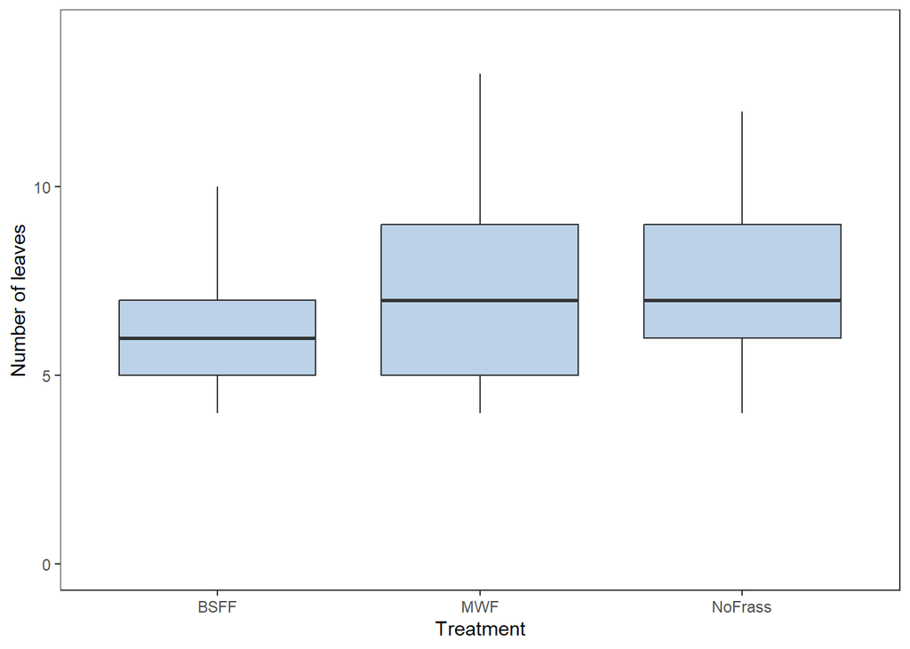

```r
ggsave("boxplot_P6.jpeg", width = 4, height = 3, dpi = 1000)


P7 <- ggplot(LN2, aes(amendment2, no_leaves2))+
  geom_boxplot(aes(fill = amendment2),
  notch = FALSE, position = position_dodge(0.9), show.legend = FALSE) +
  theme_minimal() + labs(x = "Treatment", y = "Number of leaves")+
  theme_bw() + theme(panel.grid.major = element_blank(),
  panel.grid.minor = element_blank())+
  scale_fill_manual(values = c("#BCD2E8", "#BCD2E8","#BCD2E8"))# Beau Blue
P7 + ylim(0, 14)
```

```r
ggsave("boxplot_P7.jpeg", width = 4, height = 3, dpi = 1000)
```